# Age

# 1 Description of DataSchema variable

The description of harmonised variable is the following:

- Short name: `age`
- Variable label: `Age at time of measure`
- Variable description: `Age of participant at each wave`
- Domain: `Socio-demographic and economic characteristics`
- Value type: `Continuous`
- Category missings:

| **Code** | **Category Label** |
| --- | --- |
| 991 | CAPI/interviewer error |
| 992 | Impute |
| 993 | Disable to measure |
| 994 | Not attempt/not done |
| 995 | Does not answer |
| 996 | Not applicable |
| 997 | Refuse |
| 998 | Do not know |
| 999 | Missing |

# 2 Data process

## 2.1 England

### 2.1.1 Wave 1

#### 2.1.1.1 Study-specific variable description

| **Name** | `age` | `ybirth` | `yintw` |
| --- | --- | --- | --- |
| **Label** | `age: copy of indage/dhager` | `Year of birth` | `Year of interview` |
| **Table name** | `wave_1_ifs_derived_variables` | `elsa_w1_hd`[^1] | `elsa_w1_hd`[^2] |
| **Missings** | `99 = age in years on or before 29/02/1912; -8 = Don't Know` |  |  |
| **Description** |  |  |  |

age

| Sample size | Missing values |
| --- | --- |
| 12099 | 95 |

Summary

| Min. | 1st Qu. | Median | Mean | 3rd Qu. | Max. |
| --- | --- | --- | --- | --- | --- |
| 20 | 55 | 63 | 63.91 | 72 | 90 |

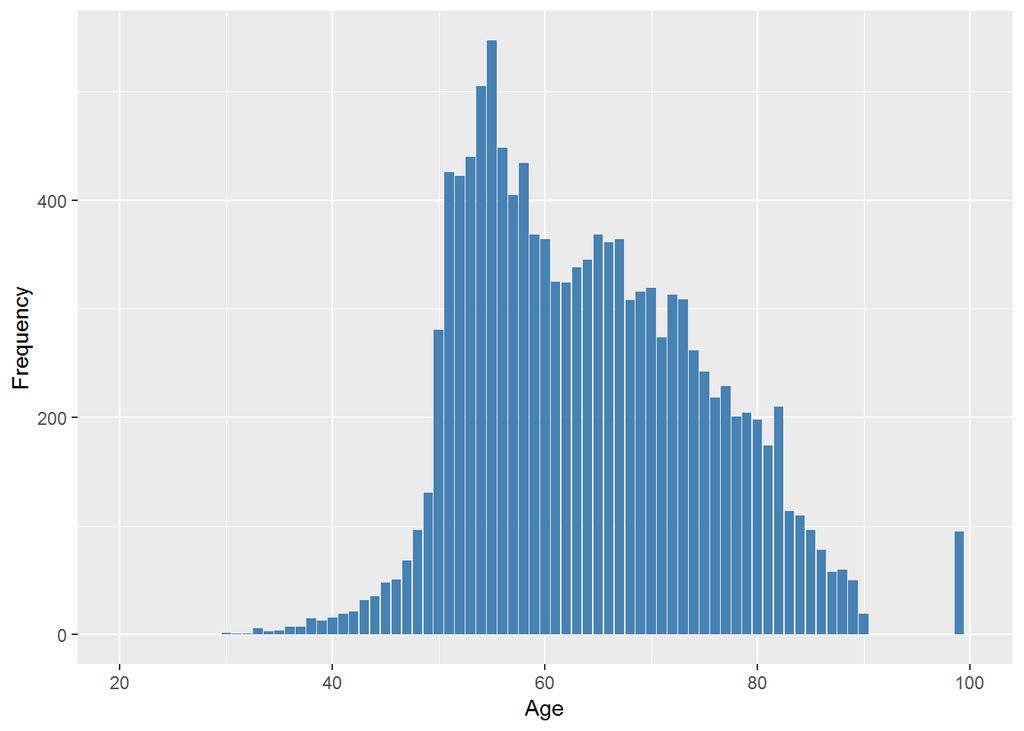

ybirth

| Sample size | Missing values |
| --- | --- |
| 12099 | 0 |

Summary

| Min. | 1st Qu. | Median | Mean | 3rd Qu. | Max. |
| --- | --- | --- | --- | --- | --- |
| 1908 | 1929 | 1939 | 1938 | 1946 | 1981 |

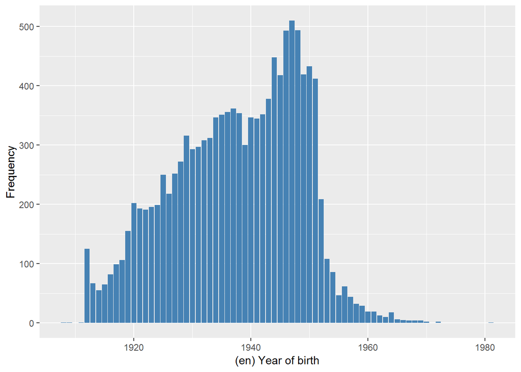

yintw

| Sample size | Missing values |
| --- | --- |
| 12099 | 0 |

Summary

|  | 2002 | 2003 |
| --- | --- | --- |
| Frequency | 10585.00 | 1514.00 |
| Percentage | 87.49 | 12.51 |

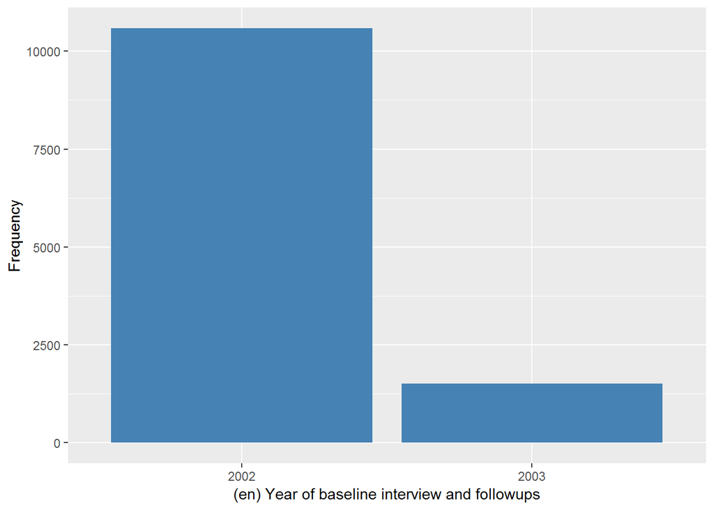

#### 2.1.1.2 Harmonisation algorithm

The harmonized variable is the same than the study-specific variable, but the missing values have to be recoded as follows:

- `year of interview - year of birth`

**R script:**

```r
ELSA_ds_w1 <- tibble(id = ELSA_w1_age$id)
ELSA_ds_w1$age <- car::recode(ELSA_w1_age$age, "-8=998; NA=999")
ELSA_ds_w1$age[which(ELSA_ds_w1$age %in% c(99, 998, 999))] <- ELSA_w1_age$yintw[which(ELSA_ds_w1$age %in%
    c(99, 998, 999))] - ELSA_w1_age$ybirth[which(ELSA_ds_w1$age %in% c(99, 998,
    999))]
```

#### 2.1.1.3 Statistics of the new harmonised variable

age

| Sample size | Missing values |
| --- | --- |
| 12099 | 0 |

values

|  | No-missings | 991 | 992 | 993 | 994 | 995 | 996 | 997 | 998 | 999 | NA |
| --- | --- | --- | --- | --- | --- | --- | --- | --- | --- | --- | --- |
| Frequency | 12099 | 0 | 0 | 0 | 0 | 0 | 0 | 0 | 0 | 0 | 0 |
| Percentage | 100 | 0 | 0 | 0 | 0 | 0 | 0 | 0 | 0 | 0 | 0 |

Summary

| Min. | 1st Qu. | Median | Mean | 3rd Qu. | Max. |
| --- | --- | --- | --- | --- | --- |
| 20 | 55 | 63 | 64.12 | 72 | 94 |

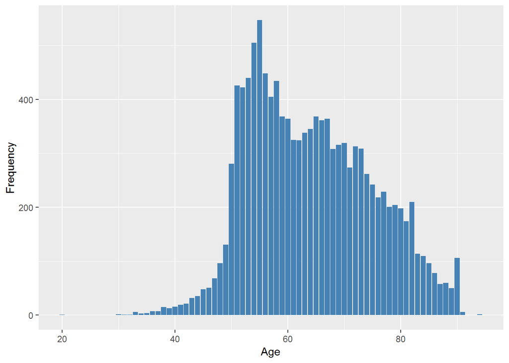

#### 2.1.1.4 Validation

The quantity of non-missing values of the initial variable which disagree with the harmonised variable is: 0

Frequencies of difference between the study-specific variable age and the age computed as year of interview - year of birth

| val | frq | label | raw.prc | valid.prc | cum.prc |
| --- | --- | --- | --- | --- | --- |
| 0 | 6121 |  | 50.59 | 50.99 | 50.99 |
| 1 | 5874 |  | 48.55 | 48.93 | 99.93 |
| 2 | 4 |  | 0.03 | 0.03 | 99.96 |
| 3 | 2 |  | 0.02 | 0.02 | 99.98 |
| 5 | 1 |  | 0.01 | 0.01 | 99.98 |
| 8 | 1 |  | 0.01 | 0.01 | 99.99 |
| 10 | 1 |  | 0.01 | 0.01 | 100.00 |
| NA | 95 |  | 0.79 | NA | NA |

Individuals with difference greater than 2

| id | age | ybirth | yintw | cage | diff |
| --- | --- | --- | --- | --- | --- |
| 106246 | 61 | 1951 | 2002 | 51 | 10 |
| 106748 | 54 | 1945 | 2002 | 57 | 3 |
| 117682 | 57 | 1942 | 2002 | 60 | 3 |
| 118379 | 53 | 1944 | 2002 | 58 | 5 |
| 120623 | 46 | 1948 | 2002 | 54 | 8 |

### 2.1.2 Wave 2

#### 2.1.2.1 Study-specific variable description

| **Name** | `age` | `ybirth` | `yintw` |
| --- | --- | --- | --- |
| **Label** | `age: copy of indage/dhager` | `Year of birth` | `Year of interview` |
| **Table name** | `wave_2_ifs_derived_variables` | `elsa_w2_hd`[^3] | `elsa_w2_hd`[^4] |
| **Missings** | `99 = age in years on or before 29/02/1912; -8 = Don't Know` |  |  |
| **Description** |  |  |  |

age

| Sample size | Missing values |
| --- | --- |
| 9432 | 109 |

Summary

| Min. | 1st Qu. | Median | Mean | 3rd Qu. | Max. |
| --- | --- | --- | --- | --- | --- |
| 17 | 57 | 64 | 65.4 | 73 | 89 |

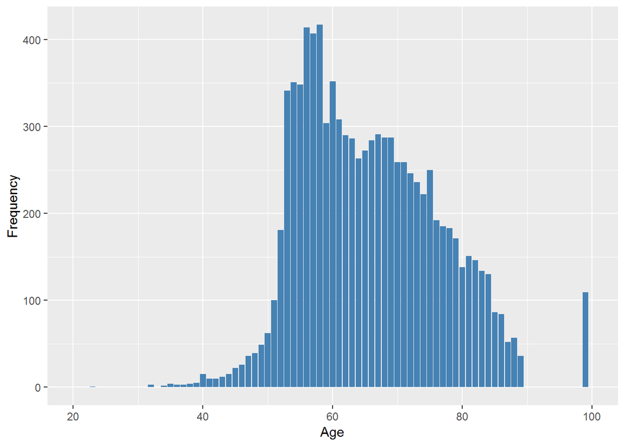

ybirth

| Sample size | Missing values |
| --- | --- |
| 9432 | 0 |

Summary

| Min. | 1st Qu. | Median | Mean | 3rd Qu. | Max. |
| --- | --- | --- | --- | --- | --- |
| 1908 | 1931 | 1939 | 1938 | 1947 | 1987 |

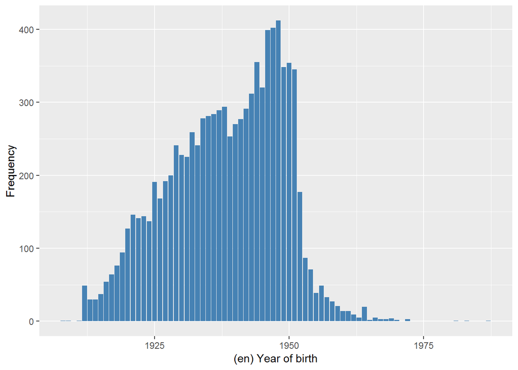

yintw

| Sample size | Missing values |
| --- | --- |
| 9432 | 0 |

Summary

|  | 2004 | 2005 |
| --- | --- | --- |
| Frequency | 5240.00 | 4192.00 |
| Percentage | 55.56 | 44.44 |

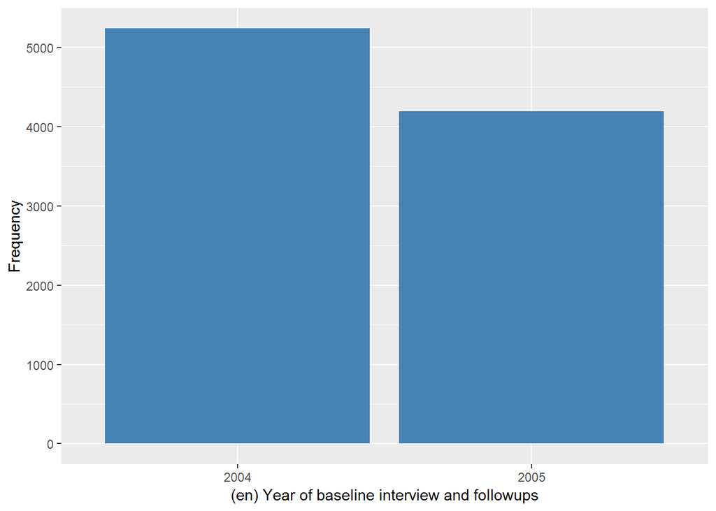

#### 2.1.2.2 Harmonisation algorithm

The harmonized variable is the same than the study-specific variable, but the missing values have to be recoded as follows:

- `year of interview - year of birth`

**R script:**

```r
ELSA_ds_w2 <- tibble(id = ELSA_w2_age$id)
ELSA_ds_w2$age <- car::recode(ELSA_w2_age$age, "-8=998; NA=999")
ELSA_ds_w2$age[which(ELSA_ds_w2$age %in% c(99, 998, 999))] <- ELSA_w2_age$yintw[which(ELSA_ds_w2$age %in%
    c(99, 998, 999))] - ELSA_w2_age$ybirth[which(ELSA_ds_w2$age %in% c(99, 998,
    999))]
```

#### 2.1.2.3 Statistics of the new harmonised variable

age

| Sample size | Missing values |
| --- | --- |
| 9432 | 0 |

values

|  | No-missings | 991 | 992 | 993 | 994 | 995 | 996 | 997 | 998 | 999 | NA |
| --- | --- | --- | --- | --- | --- | --- | --- | --- | --- | --- | --- |
| Frequency | 9432 | 0 | 0 | 0 | 0 | 0 | 0 | 0 | 0 | 0 | 0 |
| Percentage | 100 | 0 | 0 | 0 | 0 | 0 | 0 | 0 | 0 | 0 | 0 |

Summary

| Min. | 1st Qu. | Median | Mean | 3rd Qu. | Max. |
| --- | --- | --- | --- | --- | --- |
| 17 | 57 | 65 | 65.71 | 73 | 96 |

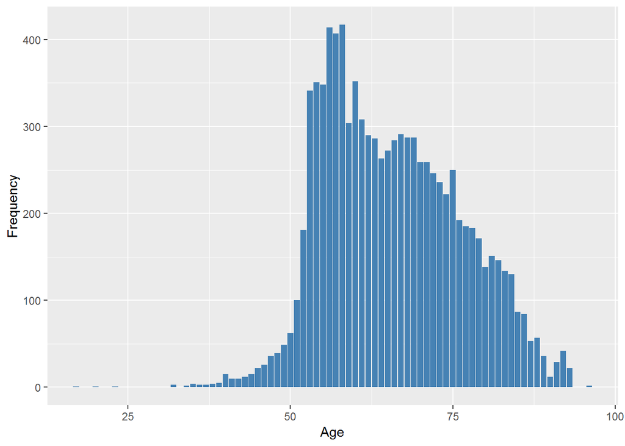

#### 2.1.2.4 Validation

The quantity of non-missing values of the initial variable which disagree with the harmonised variable is: 0

Frequencies of difference between the study-specific variable age and the age computed as year of interview - year of birth

| val | frq | label | raw.prc | valid.prc | cum.prc |
| --- | --- | --- | --- | --- | --- |
| 0 | 4572 |  | 48.47 | 49.04 | 49.04 |
| 1 | 4747 |  | 50.33 | 50.92 | 99.96 |
| 2 | 3 |  | 0.03 | 0.03 | 99.99 |
| 10 | 1 |  | 0.01 | 0.01 | 100.00 |
| NA | 109 |  | 1.16 | NA | NA |

Individuals with difference greater than 2

| id | age | ybirth | yintw | cage | diff |
| --- | --- | --- | --- | --- | --- |
| 106246 | 63 | 1951 | 2004 | 53 | 10 |

### 2.1.3 Wave 3

#### 2.1.3.1 Study-specific variable description

| **Name** | `age` | `ybirth` | `yintw` |
| --- | --- | --- | --- |
| **Label** | `age: copy of indage/dhager` | `Year of birth` | `Year of interview` |
| **Table name** | `wave_3_ifs_derived_variables` | `elsa_w3_hd`[^5] | `elsa_w3_hd`[^6] |
| **Missings** | `99 = age in years on or before 29/02/1912; -8 = Don't Know` | `998 = Do not know` |  |
| **Description** |  |  |  |

age

| Sample size | Missing values |
| --- | --- |
| 9771 | 117 |

Summary

| Min. | 1st Qu. | Median | Mean | 3rd Qu. | Max. |
| --- | --- | --- | --- | --- | --- |
| 19 | 56 | 63 | 64.15 | 72 | 90 |

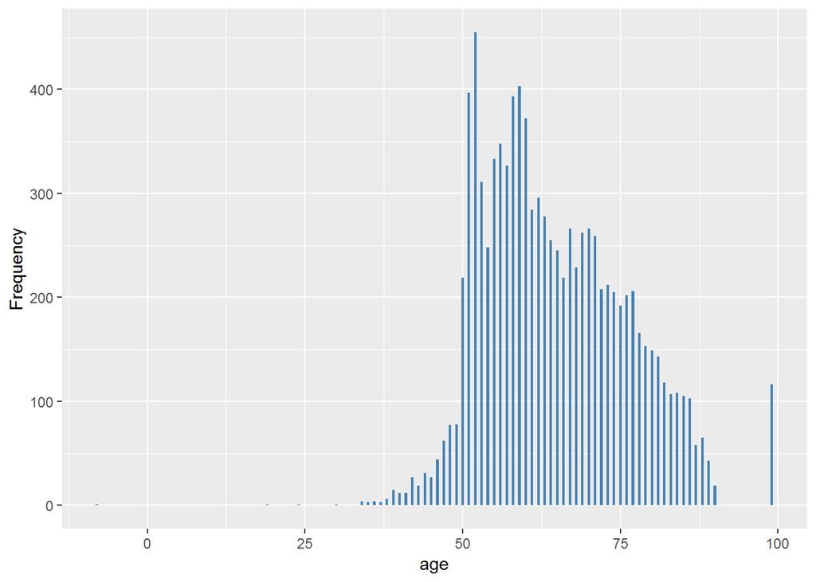

ybirth

| Sample size | Missing values |
| --- | --- |
| 9771 | 1 |

Summary

| Min. | 1st Qu. | Median | Mean | 3rd Qu. | Max. |
| --- | --- | --- | --- | --- | --- |
| 1908 | 1933 | 1943 | 1941 | 1950 | 1987 |

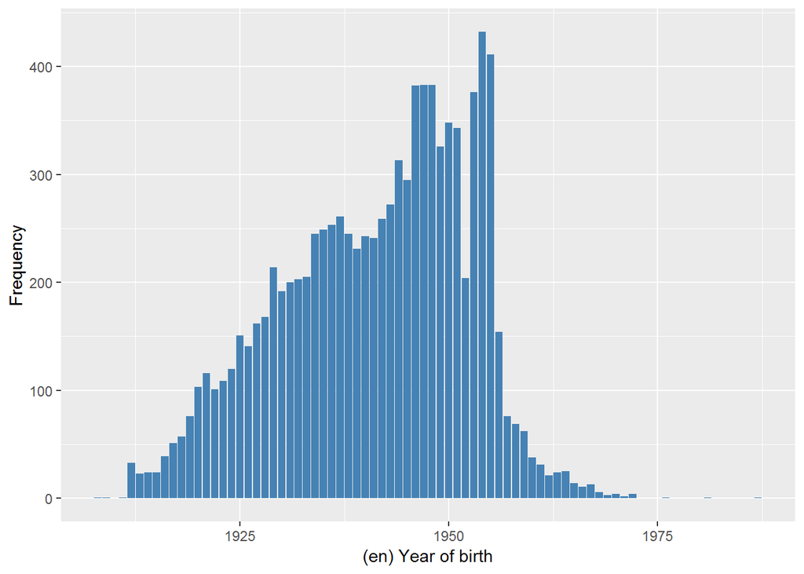

yintw

| Sample size | Missing values |
| --- | --- |
| 9771 | 0 |

Summary

|  | 2006 | 2007 |
| --- | --- | --- |
| Frequency | 8099.00 | 1672.00 |
| Percentage | 82.89 | 17.11 |

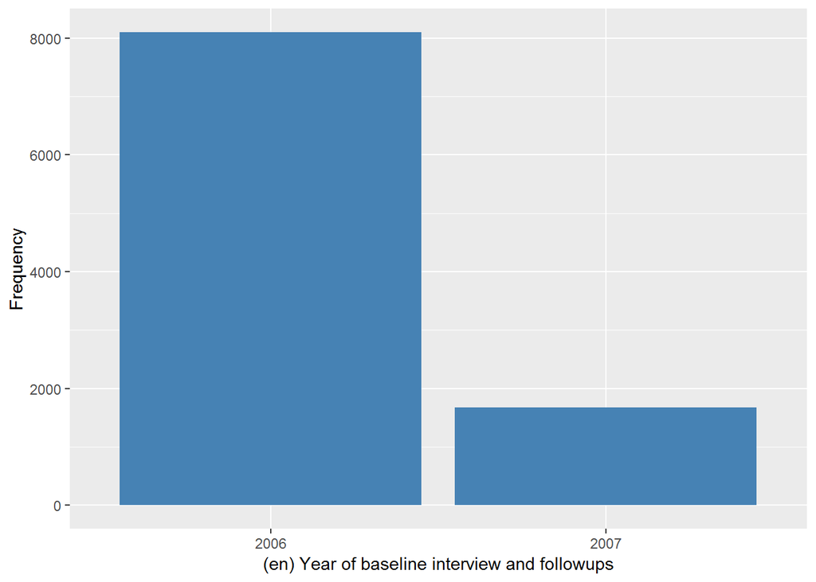

#### 2.1.3.2 Harmonisation algorithm

The harmonized variable is the same than the study-specific variable, but the missing values have to be recoded as follows:

- `year of interview - year of birth`

**R script:**

```r
ELSA_ds_w3 <- tibble(id = ELSA_w3_age$id)
ELSA_ds_w3$age <- car::recode(ELSA_w3_age$age, "-8=998; NA=999")
ELSA_ds_w3$age[which(ELSA_ds_w3$age %in% c(99, 998, 999) & ELSA_w3_age$ybirth !=
    998)] <- ELSA_w3_age$yintw[which(ELSA_ds_w3$age %in% c(99, 998, 999) & ELSA_w3_age$ybirth !=
    998)] - ELSA_w3_age$ybirth[which(ELSA_ds_w3$age %in% c(99, 998, 999) & ELSA_w3_age$ybirth !=
    998)]
```

#### 2.1.3.3 Statistics of the new harmonised variable

age

| Sample size | Missing values |
| --- | --- |
| 9771 | 1 |

values

|  | No-missings | 991 | 992 | 993 | 994 | 995 | 996 | 997 | 998 | 999 | NA |
| --- | --- | --- | --- | --- | --- | --- | --- | --- | --- | --- | --- |
| Frequency | 9770.00 | 0 | 0 | 0 | 0 | 0 | 0 | 0 | 1.00 | 0 | 0 |
| Percentage | 99.99 | 0 | 0 | 0 | 0 | 0 | 0 | 0 | 0.01 | 0 | 0 |

Summary

| Min. | 1st Qu. | Median | Mean | 3rd Qu. | Max. |
| --- | --- | --- | --- | --- | --- |
| 19 | 56 | 63 | 64.48 | 73 | 98 |

[figure not shown]

#### 2.1.3.4 Validation

The quantity of non-missing values of the initial variable which disagree with the harmonised variable is: 0

Frequencies of difference between the study-specific variable age and the age computed as year of interview - year of birth

| val | frq | label | raw.prc | valid.prc | cum.prc |
| --- | --- | --- | --- | --- | --- |
| 0 | 5744 |  | 58.79 | 59.50 | 59.50 |
| 1 | 3904 |  | 39.95 | 40.44 | 99.94 |
| 2 | 4 |  | 0.04 | 0.04 | 99.98 |
| 3 | 1 |  | 0.01 | 0.01 | 99.99 |
| 11 | 1 |  | 0.01 | 0.01 | 100.00 |
| NA | 117 |  | 1.20 | NA | NA |

Individuals with difference greater than 2

| id | age | ybirth | yintw | cage | diff |
| --- | --- | --- | --- | --- | --- |
| 121374 | 45 | 1951 | 2007 | 56 | 11 |
| 151415 | 51 | 1952 | 2006 | 54 | 3 |

### 2.1.4 Wave 4

#### 2.1.4.1 Study-specific variable description

| **Name** | `age` | `ybirth` | `yintw` |
| --- | --- | --- | --- |
| **Label** | `age: copy of indage/dhager` | `Year of birth` | `Year of interview` |
| **Table name** | `wave_4_ifs_derived_variables` | `elsa_w4_hd`[^7] | `elsa_w4_hd`[^8] |
| **Missings** | `99 = age in years on or before 29/02/1912; -8 = Don't Know` |  |  |
| **Description** |  |  |  |

age

| Sample size | Missing values |
| --- | --- |
| 11050 | 137 |

Summary

| Min. | 1st Qu. | Median | Mean | 3rd Qu. | Max. |
| --- | --- | --- | --- | --- | --- |
| 24 | 57 | 63 | 64.82 | 72 | 89 |

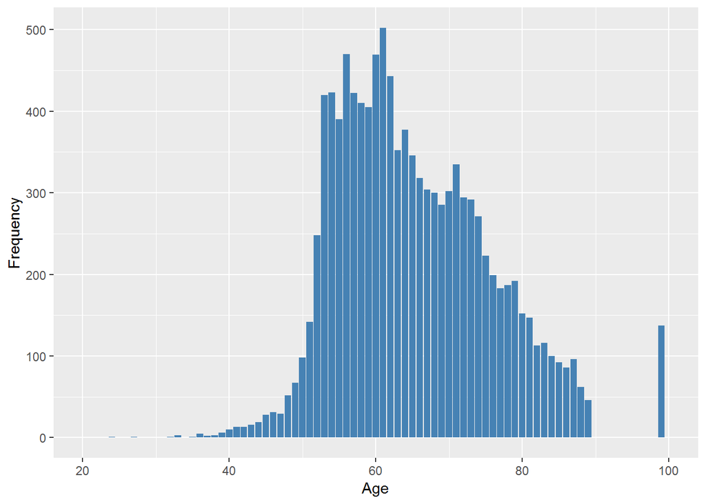

ybirth

| Sample size | Missing values |
| --- | --- |
| 11050 | 0 |

Summary

| Min. | 1st Qu. | Median | Mean | 3rd Qu. | Max. |
| --- | --- | --- | --- | --- | --- |
| 1908 | 1936 | 1944 | 1943 | 1951 | 1984 |

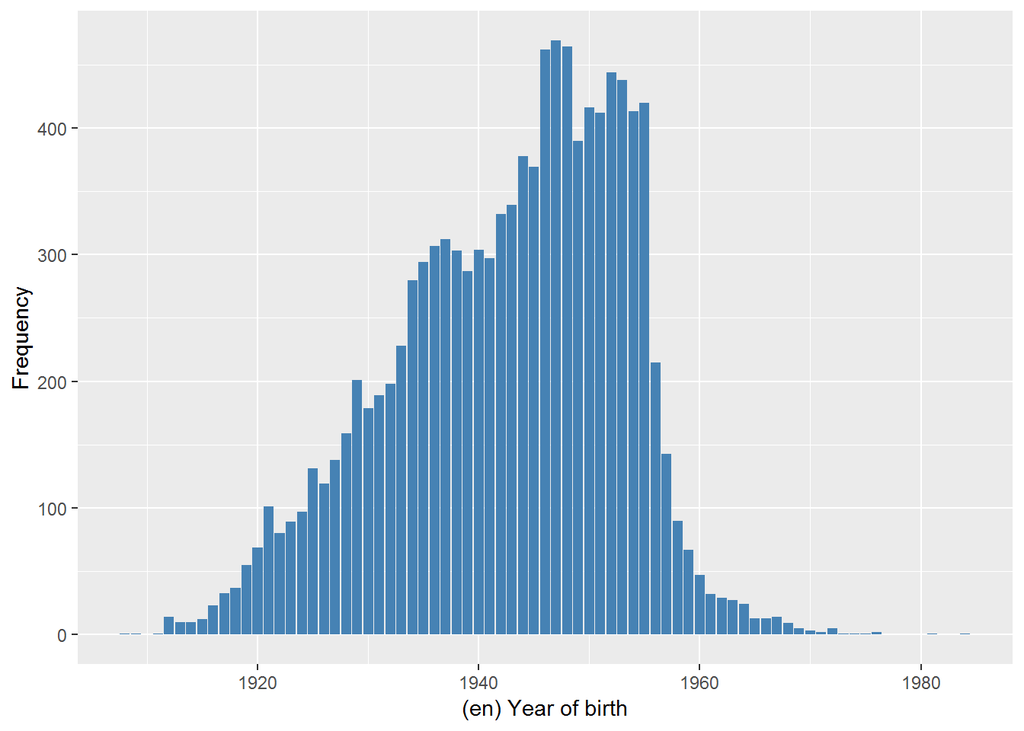

yintw

| Sample size | Missing values |
| --- | --- |
| 11050 | 0 |

Summary

|  | 2008 | 2009 |
| --- | --- | --- |
| Frequency | 7127.0 | 3923.0 |
| Percentage | 64.5 | 35.5 |

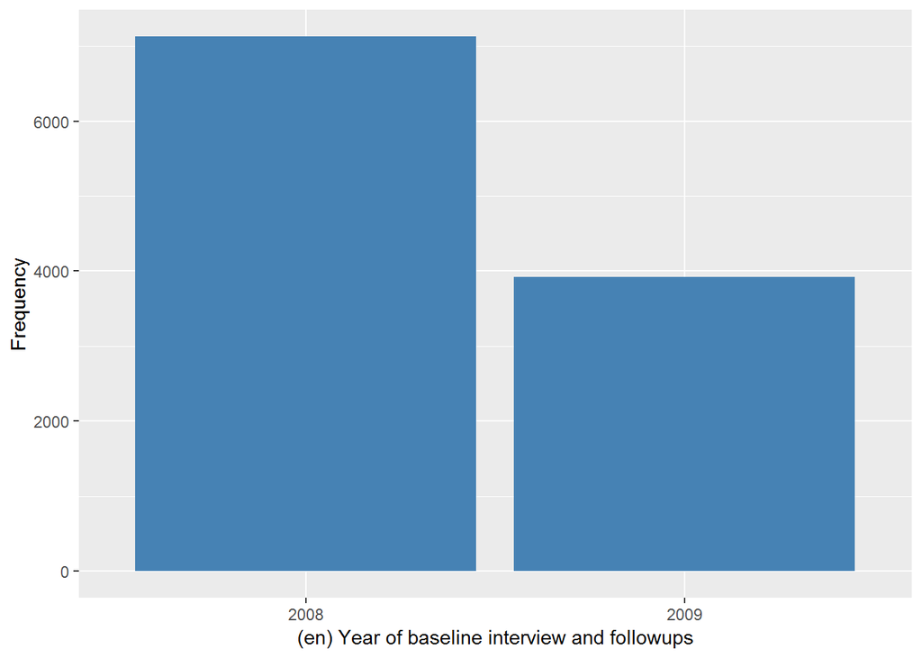

#### 2.1.4.2 Harmonisation algorithm

The harmonized variable is the same than the study-specific variable, but the missing values have to be recoded as follows:

- `year of interview - year of birth`

**R script:**

```r
ELSA_ds_w4 <- tibble(id = ELSA_w4_age$id)
ELSA_ds_w4$age <- car::recode(ELSA_w4_age$age, "-8=998; NA=999")
ELSA_ds_w4$age[which(ELSA_ds_w4$age %in% c(99, 998, 999))] <- ELSA_w4_age$yintw[which(ELSA_ds_w4$age %in%
    c(99, 998, 999))] - ELSA_w4_age$ybirth[which(ELSA_ds_w4$age %in% c(99, 998,
    999))]
```

#### 2.1.4.3 Statistics of the new harmonised variable

age

| Sample size | Missing values |
| --- | --- |
| 11050 | 0 |

values

|  | No-missings | 991 | 992 | 993 | 994 | 995 | 996 | 997 | 998 | 999 | NA |
| --- | --- | --- | --- | --- | --- | --- | --- | --- | --- | --- | --- |
| Frequency | 11050 | 0 | 0 | 0 | 0 | 0 | 0 | 0 | 0 | 0 | 0 |
| Percentage | 100 | 0 | 0 | 0 | 0 | 0 | 0 | 0 | 0 | 0 | 0 |

Summary

| Min. | 1st Qu. | Median | Mean | 3rd Qu. | Max. |
| --- | --- | --- | --- | --- | --- |
| 24 | 57 | 64 | 65.16 | 72 | 100 |

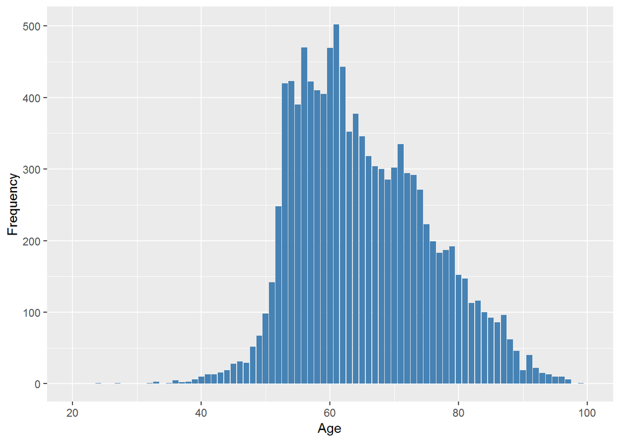

#### 2.1.4.4 Validation

The quantity of non-missing values of the initial variable which disagree with the harmonised variable is: 0

Frequencies of difference between the study-specific variable age and the age computed as year of interview - year of birth

| val | frq | label | raw.prc | valid.prc | cum.prc |
| --- | --- | --- | --- | --- | --- |
| 0 | 5435 |  | 49.19 | 49.80 | 49.80 |
| 1 | 5473 |  | 49.53 | 50.15 | 99.95 |
| 2 | 4 |  | 0.04 | 0.04 | 99.99 |
| 14 | 1 |  | 0.01 | 0.01 | 100.00 |
| NA | 137 |  | 1.24 | NA | NA |

Individuals with difference greater than 2

| id | age | ybirth | yintw | cage | diff |
| --- | --- | --- | --- | --- | --- |
| 106062 | 81 | 1941 | 2008 | 67 | 14 |

### 2.1.5 Wave 5

#### 2.1.5.1 Study-specific variable description

| **Name** | `age` | `ybirth` | `yintw` |
| --- | --- | --- | --- |
| **Label** | `age: copy of indage/dhager` | `Year of birth` | `Year of interview` |
| **Table name** | `wave_5_ifs_derived_variables` | `elsa_w5_hd`[^9] | `elsa_w5_hd`[^10] |
| **Missings** | `99 = age in years on or before 29/02/1912; -8 = Don't Know` |  |  |
| **Description** |  |  |  |

age

| Sample size | Missing values |
| --- | --- |
| 10274 | 125 |

Summary

| Min. | 1st Qu. | Median | Mean | 3rd Qu. | Max. |
| --- | --- | --- | --- | --- | --- |
| 26 | 59 | 65 | 66.39 | 73 | 90 |

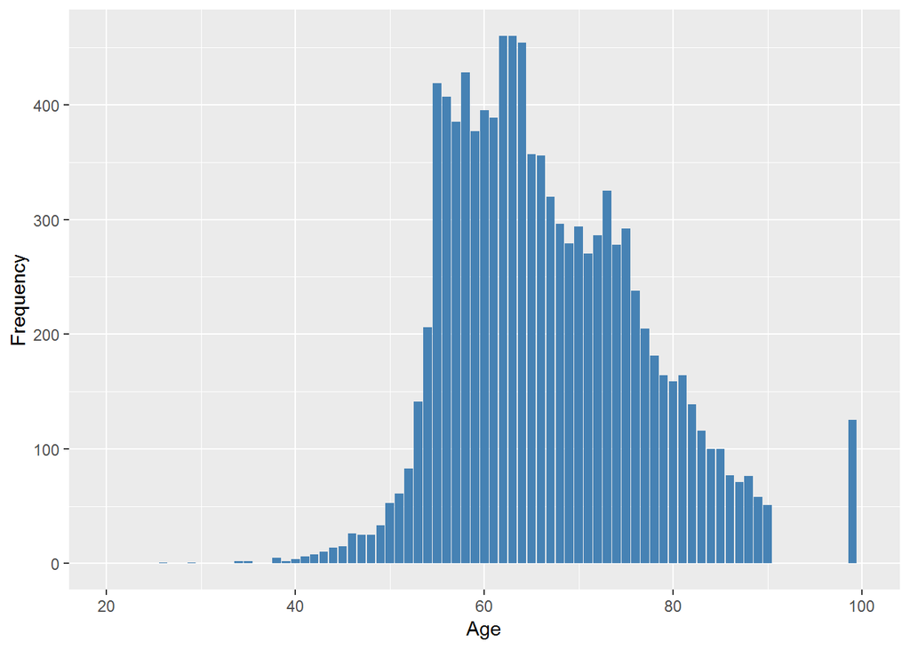

ybirth

| Sample size | Missing values |
| --- | --- |
| 10274 | 0 |

Summary

| Min. | 1st Qu. | Median | Mean | 3rd Qu. | Max. |
| --- | --- | --- | --- | --- | --- |
| 1908 | 1936 | 1945 | 1943 | 1951 | 1984 |

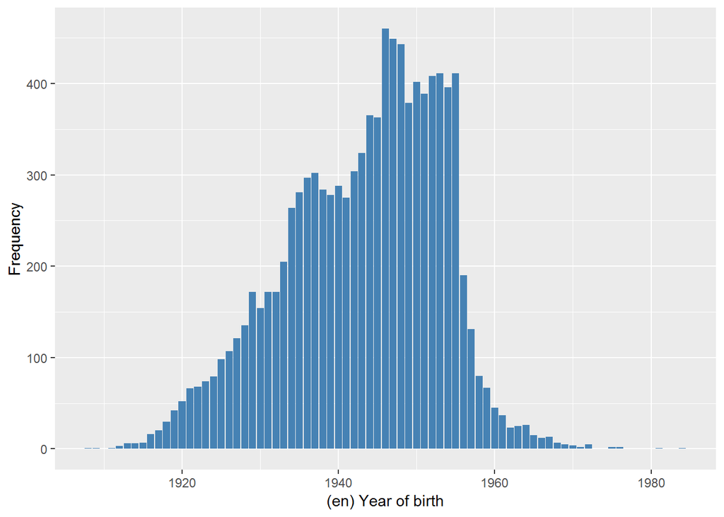

yintw

| Sample size | Missing values |
| --- | --- |
| 10274 | 0 |

Summary

|  | 2010 | 2011 |
| --- | --- | --- |
| Frequency | 7066.00 | 3208.00 |
| Percentage | 68.78 | 31.22 |

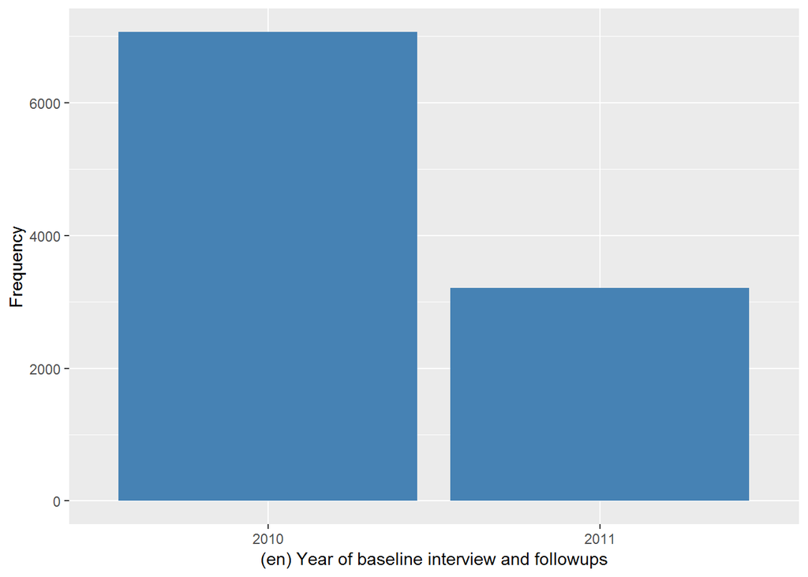

#### 2.1.5.2 Harmonisation algorithm

The harmonized variable is the same than the study-specific variable, but the missing values have to be recoded as follows:

- `year of interview - year of birth`

**R script:**

```r
ELSA_ds_w5 <- tibble(id = ELSA_w5_age$id)
ELSA_ds_w5$age <- car::recode(ELSA_w5_age$age, "-8=998; NA=999")
ELSA_ds_w5$age[which(ELSA_ds_w5$age %in% c(99, 998, 999))] <- ELSA_w5_age$yintw[which(ELSA_ds_w5$age %in%
    c(99, 998, 999))] - ELSA_w5_age$ybirth[which(ELSA_ds_w5$age %in% c(99, 998,
    999))]
```

#### 2.1.5.3 Statistics of the new harmonised variable

age

| Sample size | Missing values |
| --- | --- |
| 10274 | 0 |

values

|  | No-missings | 991 | 992 | 993 | 994 | 995 | 996 | 997 | 998 | 999 | NA |
| --- | --- | --- | --- | --- | --- | --- | --- | --- | --- | --- | --- |
| Frequency | 10274 | 0 | 0 | 0 | 0 | 0 | 0 | 0 | 0 | 0 | 0 |
| Percentage | 100 | 0 | 0 | 0 | 0 | 0 | 0 | 0 | 0 | 0 | 0 |

Summary

| Min. | 1st Qu. | Median | Mean | 3rd Qu. | Max. |
| --- | --- | --- | --- | --- | --- |
| 26 | 59 | 65 | 66.72 | 74 | 102 |

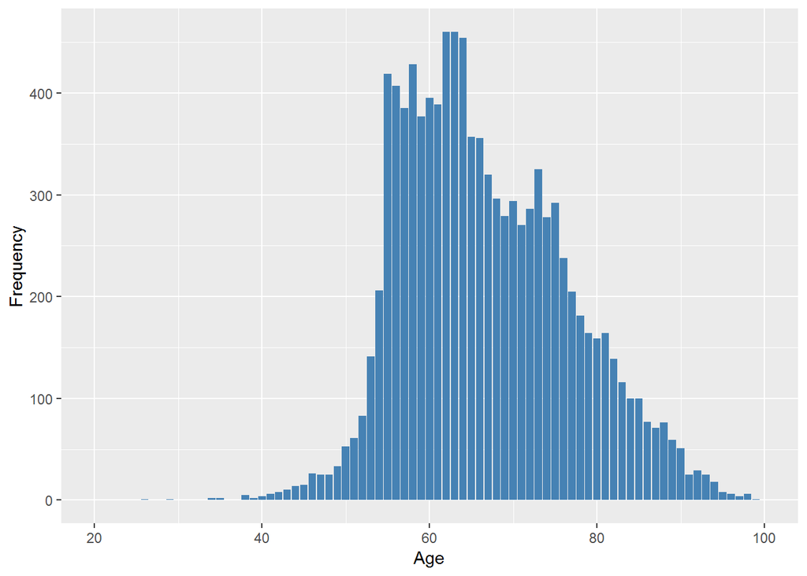

#### 2.1.5.4 Validation

The quantity of non-missing values of the initial variable which disagree with the harmonised variable is: 0

Frequencies of difference between the study-specific variable age and the age computed as year of interview - year of birth

| val | frq | label | raw.prc | valid.prc | cum.prc |
| --- | --- | --- | --- | --- | --- |
| 0 | 5786 |  | 56.32 | 57.01 | 57.01 |
| 1 | 4363 |  | 42.47 | 42.99 | 100.00 |
| NA | 125 |  | 1.22 | NA | NA |

### 2.1.6 Wave 6

#### 2.1.6.1 Study-specific variable description

| **Name** | `age` | `ybirth` | `yintw` |
| --- | --- | --- | --- |
| **Label** | `age: copy of indage/dhager` | `Year of birth` | `Year of interview` |
| **Table name** | `wave_6_ifs_derived_variables` | `elsa_w6_hd`[^11] | `elsa_w6_hd`[^12] |
| **Missings** | `99 = age in years on or before 29/02/1912; -8 = Don't Know` |  |  |
| **Description** |  |  |  |

age

| Sample size | Missing values |
| --- | --- |
| 10601 | 157 |

Summary

| Min. | 1st Qu. | Median | Mean | 3rd Qu. | Max. |
| --- | --- | --- | --- | --- | --- |
| 28 | 59 | 65 | 66.13 | 73 | 90 |

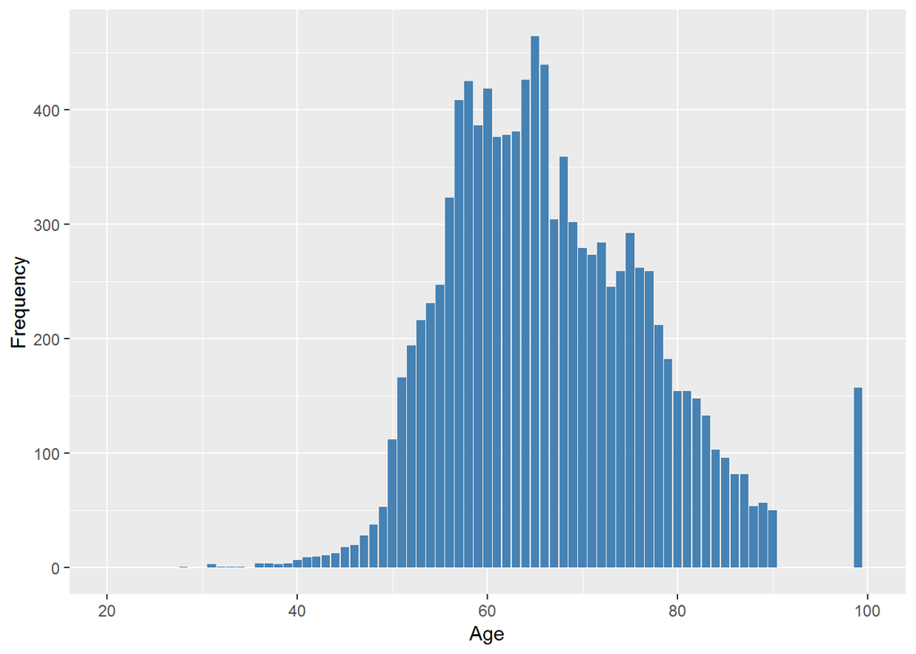

ybirth

| Sample size | Missing values |
| --- | --- |
| 10601 | 0 |

Summary

| Min. | 1st Qu. | Median | Mean | 3rd Qu. | Max. |
| --- | --- | --- | --- | --- | --- |
| 1911 | 1938 | 1946 | 1945 | 1953 | 1984 |

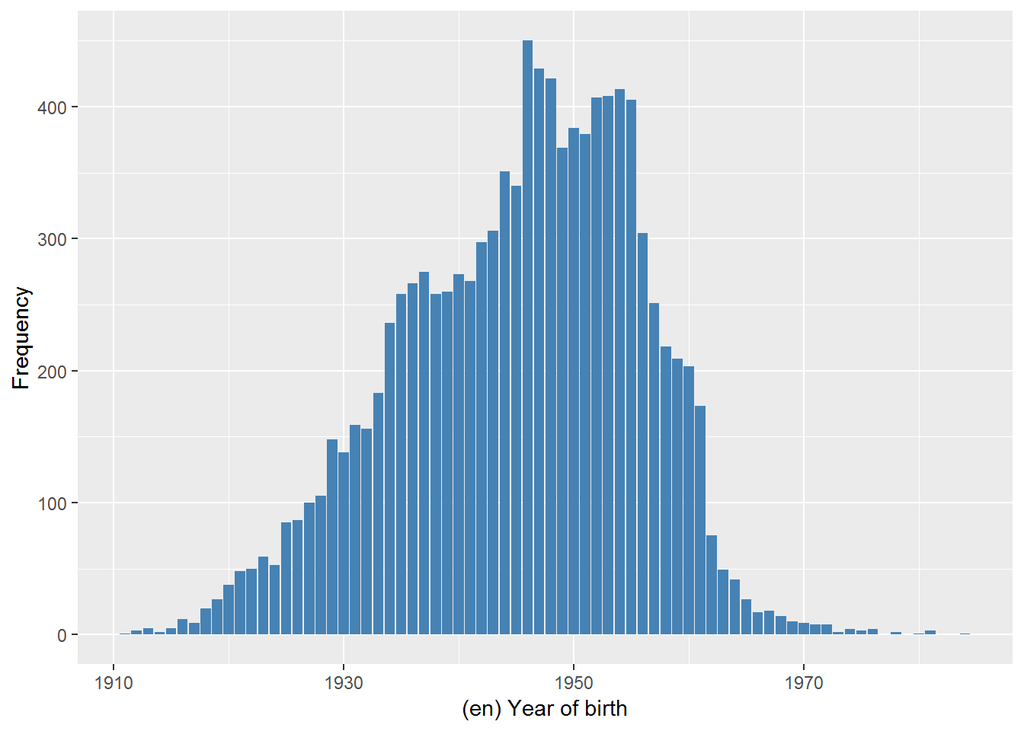

yintw

| Sample size | Missing values |
| --- | --- |
| 10601 | 0 |

Summary

|  | 2012 | 2013 |
| --- | --- | --- |
| Frequency | 9047.00 | 1554.00 |
| Percentage | 85.34 | 14.66 |

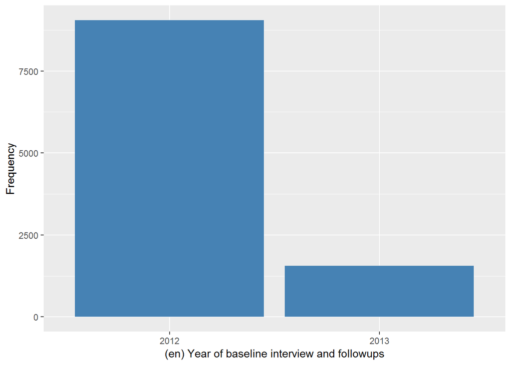

#### 2.1.6.2 Harmonisation algorithm

The harmonized variable is the same than the study-specific variable, but the missing values have to be recoded as follows:

- `year of interview - year of birth`

**R script:**

```r
ELSA_ds_w6 <- tibble(id = ELSA_w6_age$id)
ELSA_ds_w6$age <- car::recode(ELSA_w6_age$age, "-8=998; NA=999")
ELSA_ds_w6$age[which(ELSA_ds_w6$age %in% c(99, 998, 999))] <- ELSA_w6_age$yintw[which(ELSA_ds_w6$age %in%
    c(99, 998, 999))] - ELSA_w6_age$ybirth[which(ELSA_ds_w6$age %in% c(99, 998,
    999))]
```

#### 2.1.6.3 Statistics of the new harmonised variable

age

| Sample size | Missing values |
| --- | --- |
| 10601 | 0 |

values

|  | No-missings | 991 | 992 | 993 | 994 | 995 | 996 | 997 | 998 | 999 | NA |
| --- | --- | --- | --- | --- | --- | --- | --- | --- | --- | --- | --- |
| Frequency | 10601 | 0 | 0 | 0 | 0 | 0 | 0 | 0 | 0 | 0 | 0 |
| Percentage | 100 | 0 | 0 | 0 | 0 | 0 | 0 | 0 | 0 | 0 | 0 |

Summary

| Min. | 1st Qu. | Median | Mean | 3rd Qu. | Max. |
| --- | --- | --- | --- | --- | --- |
| 28 | 59 | 65 | 66.53 | 74 | 101 |

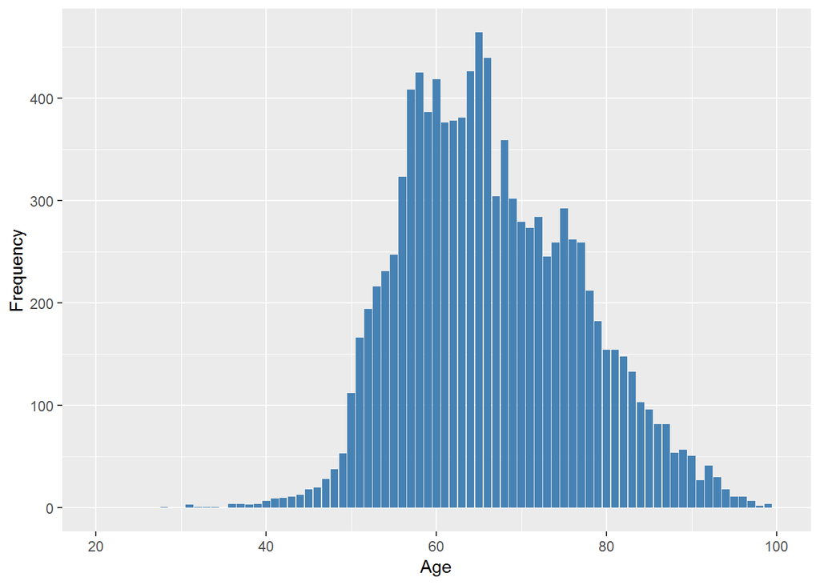

#### 2.1.6.4 Validation

The quantity of non-missing values of the initial variable which disagree with the harmonised variable is: 0

Frequencies of difference between the study-specific variable age and the age computed as year of interview - year of birth

| val | frq | label | raw.prc | valid.prc | cum.prc |
| --- | --- | --- | --- | --- | --- |
| 0 | 6807 |  | 64.21 | 65.18 | 65.18 |
| 1 | 3634 |  | 34.28 | 34.80 | 99.97 |
| 2 | 1 |  | 0.01 | 0.01 | 99.98 |
| 3 | 1 |  | 0.01 | 0.01 | 99.99 |
| 4 | 1 |  | 0.01 | 0.01 | 100.00 |
| NA | 157 |  | 1.48 | NA | NA |

Individuals with difference greater than 2

| id | age | ybirth | yintw | cage | diff |
| --- | --- | --- | --- | --- | --- |
| 116908 | 84 | 1932 | 2012 | 80 | 4 |
| 120955 | 65 | 1944 | 2012 | 68 | 3 |

### 2.1.7 Wave 7

#### 2.1.7.1 Study-specific variable description

| **Name** | `age` | `ybirth` | `yintw` |
| --- | --- | --- | --- |
| **Label** | `age: copy of indage/dhager` | `Year of birth` | `Year of interview` |
| **Table name** | `wave7_dv` | `elsa_w7_hd`[^13] |  |
| **Missings** | `99 = age in years on or before 29/02/1912` |  |  |
| **Description** |  |  |  |

age

| Sample size | Missing values |
| --- | --- |
| 9666 | 157 |

Summary

| Min. | 1st Qu. | Median | Mean | 3rd Qu. | Max. |
| --- | --- | --- | --- | --- | --- |
| 29 | 60 | 66 | 66.92 | 74 | 90 |

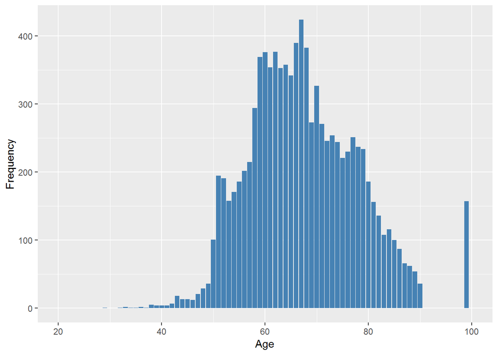

ybirth

| Sample size | Missing values |
| --- | --- |
| 9666 | 0 |

Summary

| Min. | 1st Qu. | Median | Mean | 3rd Qu. | Max. |
| --- | --- | --- | --- | --- | --- |
| 1911 | 1939 | 1947 | 1946 | 1954 | 1985 |

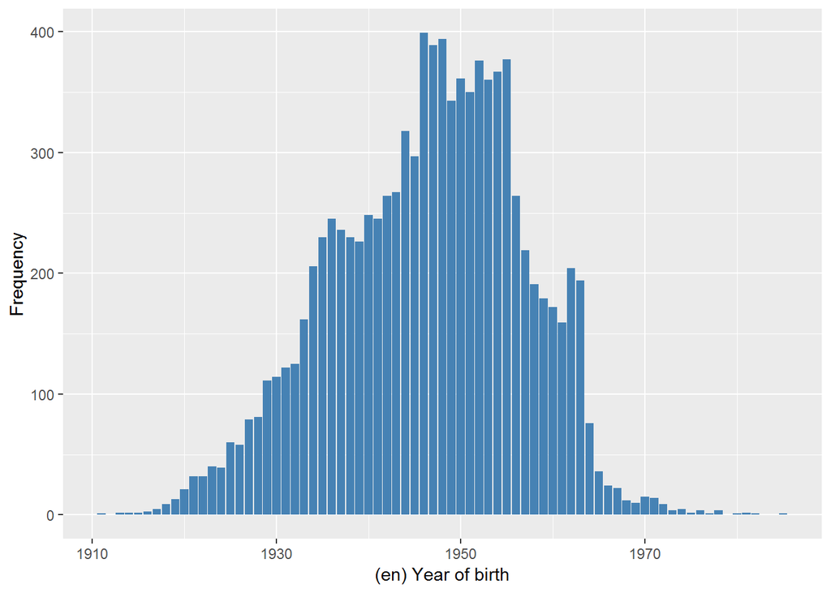

yintw

| Sample size | Missing values |
| --- | --- |
| 9666 | 0 |

Summary

|  | 2014 | 2015 |
| --- | --- | --- |
| Frequency | 7695.00 | 1971.00 |
| Percentage | 79.61 | 20.39 |

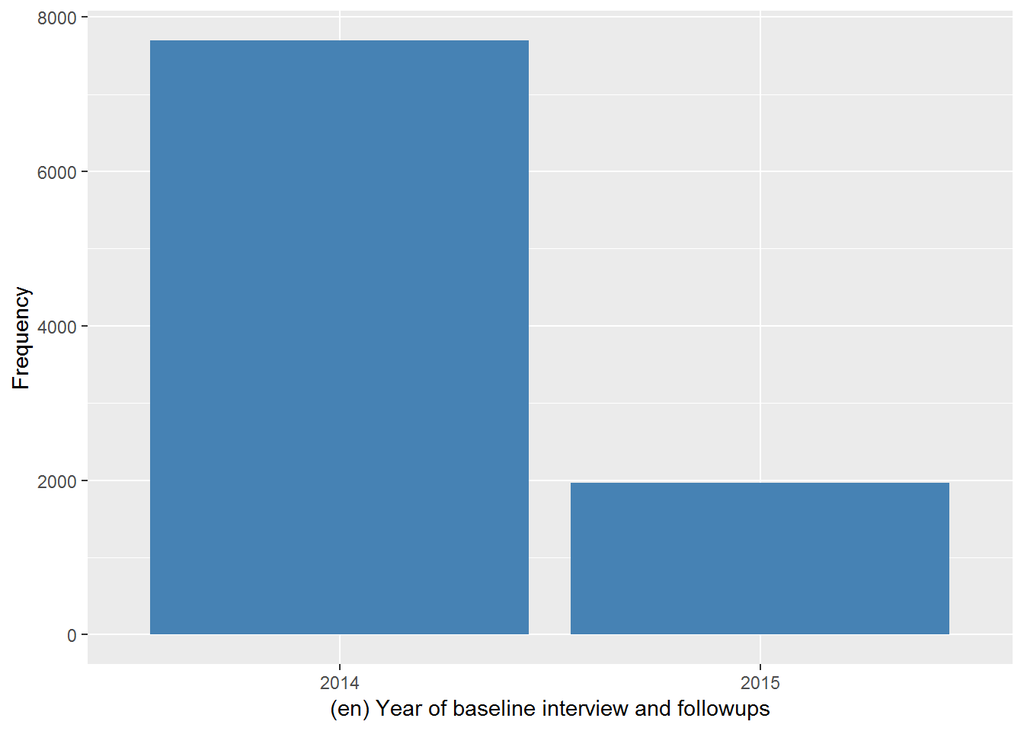

#### 2.1.7.2 Harmonisation algorithm

The harmonized variable is the same than the study-specific variable, but the missing values have to be recoded as follows:

- `year of interview - year of birth`

**R script:**

```r
ELSA_ds_w7 <- tibble(id = ELSA_w7_age$id)
ELSA_ds_w7$age <- car::recode(ELSA_w7_age$age, "NA=999")
ELSA_ds_w7$age[which(ELSA_ds_w7$age %in% c(99, 998, 999))] <- ELSA_w7_age$yintw[which(ELSA_ds_w7$age %in%
    c(99, 998, 999))] - ELSA_w7_age$ybirth[which(ELSA_ds_w7$age %in% c(99, 998,
    999))]
```

#### 2.1.7.3 Statistics of the new harmonised variable

age

| Sample size | Missing values |
| --- | --- |
| 9666 | 0 |

values

|  | No-missings | 991 | 992 | 993 | 994 | 995 | 996 | 997 | 998 | 999 | NA |
| --- | --- | --- | --- | --- | --- | --- | --- | --- | --- | --- | --- |
| Frequency | 9666 | 0 | 0 | 0 | 0 | 0 | 0 | 0 | 0 | 0 | 0 |
| Percentage | 100 | 0 | 0 | 0 | 0 | 0 | 0 | 0 | 0 | 0 | 0 |

Summary

| Min. | 1st Qu. | Median | Mean | 3rd Qu. | Max. |
| --- | --- | --- | --- | --- | --- |
| 29 | 60 | 67 | 67.36 | 75 | 104 |

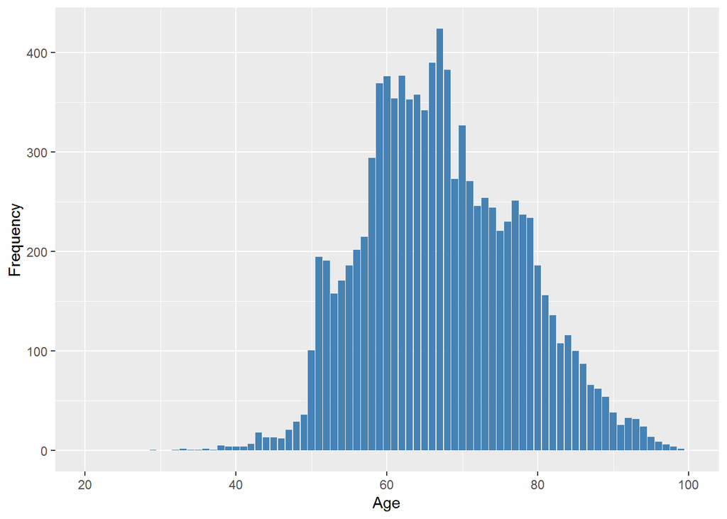

#### 2.1.7.4 Validation

The quantity of non-missing values of the initial variable which disagree with the harmonised variable is: 0

Frequencies of difference between the study-specific variable age and the age computed as year of interview - year of birth

| val | frq | label | raw.prc | valid.prc | cum.prc |
| --- | --- | --- | --- | --- | --- |
| 0 | 5805 |  | 60.06 | 61.05 | 61.05 |
| 1 | 3701 |  | 38.29 | 38.92 | 99.97 |
| 2 | 1 |  | 0.01 | 0.01 | 99.98 |
| 3 | 1 |  | 0.01 | 0.01 | 99.99 |
| 4 | 1 |  | 0.01 | 0.01 | 100.00 |
| NA | 157 |  | 1.62 | NA | NA |

Individuals with difference greater than 2

| id | age | ybirth | yintw | cage | diff |
| --- | --- | --- | --- | --- | --- |
| 116908 | 86 | 1932 | 2014 | 82 | 4 |
| 120955 | 67 | 1944 | 2014 | 70 | 3 |

## 2.2 Summary of descriptive statistics of the harmonised variable accross populations and waves

Age

| age | W1 | W2 | W3 | W4 | W5 | W6 | W7 |
| --- | --- | --- | --- | --- | --- | --- | --- |
| Min. | 20 | 17 | 19 | 24 | 26 | 28 | 29 |
| 1st Qu. | 55 | 57 | 56 | 57 | 59 | 59 | 60 |
| Median | 63 | 65 | 63 | 64 | 65 | 65 | 67 |
| Mean | 64.12 | 65.71 | 64.48 | 65.16 | 66.72 | 66.53 | 67.36 |
| 3rd Qu. | 72 | 73 | 73 | 72 | 74 | 74 | 75 |
| Max. | 94 | 96 | 98 | 100 | 102 | 101 | 104 |
| No-missings | 12099 | 9432 | 9770 | 11050 | 10274 | 10601 | 9666 |
| 991 | 0 | 0 | 0 | 0 | 0 | 0 | 0 |
| 992 | 0 | 0 | 0 | 0 | 0 | 0 | 0 |
| 993 | 0 | 0 | 0 | 0 | 0 | 0 | 0 |
| 994 | 0 | 0 | 0 | 0 | 0 | 0 | 0 |
| 995 | 0 | 0 | 0 | 0 | 0 | 0 | 0 |
| 996 | 0 | 0 | 0 | 0 | 0 | 0 | 0 |
| 997 | 0 | 0 | 0 | 0 | 0 | 0 | 0 |
| 998 | 0 | 0 | 1 | 0 | 0 | 0 | 0 |
| 999 | 0 | 0 | 0 | 0 | 0 | 0 | 0 |
| NA | 0 | 0 | 0 | 0 | 0 | 0 | 0 |
| sample size | 12099 | 9432 | 9771 | 11050 | 10274 | 10601 | 9666 |

# 3 Quality estimation

Individuals with incompatible data are specified in validations along waves.

[^1]: Table from the Harmonised Datasets.
[^2]: Table from the Harmonised Datasets.
[^3]: Table from the Harmonised Datasets.
[^4]: Table from the Harmonised Datasets.
[^5]: Table from the Harmonised Datasets.
[^6]: Table from the Harmonised Datasets.
[^7]: Table from the Harmonised Datasets.
[^8]: Table from the Harmonised Datasets.
[^9]: Table from the Harmonised Datasets.
[^10]: Table from the Harmonised Datasets.
[^11]: Table from the Harmonised Datasets.
[^12]: Table from the Harmonised Datasets.
[^13]: Table from the Harmonised Datasets.